# ASML3 Lab 1 – Taster of modern R for data manipulation and visualisation

This is the first lab so we want to take the opportunity to look at some data exploration: although the maths and modelling is exciting, data exploration is absolutely critical to any real-world application. Never blindly run into building a machine learning model without exploring your data first!!

We are also going to introduce the modern approach to using R which sets it apart from other data science languages in functionality and ease. This is a quick taster, because there are a rich collection of tools which would take many hours to teach in a lab. The syntax may be very unfamiliar at first, but it makes modern R code substantially more readable and understandable than base R or other languages.

It is highly recommended that you read the free online book at https://r4ds.had.co.nz/ in your own time if you want to get better at data manipulation and visualisation in R, since we have limited time and will focus on the modelling aspects in the remaining labs.

First, we download a dataset on hotel bookings. The `readr` package reads in data to the updated version of a data frame, called a tibble and performs more checks that the standard R `read.csv()`. We then use `View()` to have a look at the data in the RStudio viewer.

```r
hotels <- readr::read_csv("https://raw.githubusercontent.com/rfordatascience/tidytuesday/master/data/2020/2020-02-11/hotels.csv")
View(hotels)
```

Notice the function above might look unusual `readr::read_csv(...)`. This is the syntax to run a function (`read_csv`) from inside a package (`readr`) without having to load the whole package into our session. When you only plan to use one or two functions in a package this is a good idea to avoid possible function name clashes.

Open the web page here to read about this data set:

https://github.com/rfordatascience/tidytuesday/blob/master/data/2020/2020-02-11/readme.md

This data is from a [#tidytuesday](https://twitter.com/search?q=%23tidytuesday) challenge. These are fun challenges which run most weeks on Twitter where people post their exploration of a different data set which is proposed each week. I highly encourage you to follow and participate in them if you want to improve your general data science skills (wrangling and visualisation especially) … you can learn a lot about these hands on aspects of data science from looking at what people do. This course will be more about machine learning modelling from here on out.

First, let’s have a look at the summary of the data using the `skimr` package.

```r
library("skimr")
skim(hotels)
```

Data summary

| Name | hotels |
| --- | --- |
| Number of rows | 119390 |
| Number of columns | 32 |
| _______________________ |  |
| Column type frequency: |  |
| character | 13 |
| Date | 1 |
| numeric | 18 |
| ________________________ |  |
| Group variables | None |

**Variable type: character**

| skim_variable | n_missing | complete_rate | min | max | empty | n_unique | whitespace |
| --- | --- | --- | --- | --- | --- | --- | --- |
| hotel | 0 | 1 | 10 | 12 | 0 | 2 | 0 |
| arrival_date_month | 0 | 1 | 3 | 9 | 0 | 12 | 0 |
| meal | 0 | 1 | 2 | 9 | 0 | 5 | 0 |
| country | 0 | 1 | 2 | 4 | 0 | 178 | 0 |
| market_segment | 0 | 1 | 6 | 13 | 0 | 8 | 0 |
| distribution_channel | 0 | 1 | 3 | 9 | 0 | 5 | 0 |
| reserved_room_type | 0 | 1 | 1 | 1 | 0 | 10 | 0 |
| assigned_room_type | 0 | 1 | 1 | 1 | 0 | 12 | 0 |
| deposit_type | 0 | 1 | 10 | 10 | 0 | 3 | 0 |
| agent | 0 | 1 | 1 | 4 | 0 | 334 | 0 |
| company | 0 | 1 | 1 | 4 | 0 | 353 | 0 |
| customer_type | 0 | 1 | 5 | 15 | 0 | 4 | 0 |
| reservation_status | 0 | 1 | 7 | 9 | 0 | 3 | 0 |

**Variable type: Date**

| skim_variable | n_missing | complete_rate | min | max | median | n_unique |
| --- | --- | --- | --- | --- | --- | --- |
| reservation_status_date | 0 | 1 | 2014-10-17 | 2017-09-14 | 2016-08-07 | 926 |

**Variable type: numeric**

| skim_variable | n_missing | complete_rate | mean | sd | p0 | p25 | p50 | p75 | p100 | hist |
| --- | --- | --- | --- | --- | --- | --- | --- | --- | --- | --- |
| is_canceled | 0 | 1 | 0.37 | 0.48 | 0.00 | 0.00 | 0.00 | 1 | 1 | ▇▁▁▁▅ |
| lead_time | 0 | 1 | 104.01 | 106.86 | 0.00 | 18.00 | 69.00 | 160 | 737 | ▇▂▁▁▁ |
| arrival_date_year | 0 | 1 | 2016.16 | 0.71 | 2015.00 | 2016.00 | 2016.00 | 2017 | 2017 | ▃▁▇▁▆ |
| arrival_date_week_number | 0 | 1 | 27.17 | 13.61 | 1.00 | 16.00 | 28.00 | 38 | 53 | ▅▇▇▇▅ |
| arrival_date_day_of_month | 0 | 1 | 15.80 | 8.78 | 1.00 | 8.00 | 16.00 | 23 | 31 | ▇▇▇▇▆ |
| stays_in_weekend_nights | 0 | 1 | 0.93 | 1.00 | 0.00 | 0.00 | 1.00 | 2 | 19 | ▇▁▁▁▁ |
| stays_in_week_nights | 0 | 1 | 2.50 | 1.91 | 0.00 | 1.00 | 2.00 | 3 | 50 | ▇▁▁▁▁ |
| adults | 0 | 1 | 1.86 | 0.58 | 0.00 | 2.00 | 2.00 | 2 | 55 | ▇▁▁▁▁ |
| children | 4 | 1 | 0.10 | 0.40 | 0.00 | 0.00 | 0.00 | 0 | 10 | ▇▁▁▁▁ |
| babies | 0 | 1 | 0.01 | 0.10 | 0.00 | 0.00 | 0.00 | 0 | 10 | ▇▁▁▁▁ |
| is_repeated_guest | 0 | 1 | 0.03 | 0.18 | 0.00 | 0.00 | 0.00 | 0 | 1 | ▇▁▁▁▁ |
| previous_cancellations | 0 | 1 | 0.09 | 0.84 | 0.00 | 0.00 | 0.00 | 0 | 26 | ▇▁▁▁▁ |
| previous_bookings_not_canceled | 0 | 1 | 0.14 | 1.50 | 0.00 | 0.00 | 0.00 | 0 | 72 | ▇▁▁▁▁ |
| booking_changes | 0 | 1 | 0.22 | 0.65 | 0.00 | 0.00 | 0.00 | 0 | 21 | ▇▁▁▁▁ |
| days_in_waiting_list | 0 | 1 | 2.32 | 17.59 | 0.00 | 0.00 | 0.00 | 0 | 391 | ▇▁▁▁▁ |
| adr | 0 | 1 | 101.83 | 50.54 | -6.38 | 69.29 | 94.58 | 126 | 5400 | ▇▁▁▁▁ |
| required_car_parking_spaces | 0 | 1 | 0.06 | 0.25 | 0.00 | 0.00 | 0.00 | 0 | 8 | ▇▁▁▁▁ |
| total_of_special_requests | 0 | 1 | 0.57 | 0.79 | 0.00 | 0.00 | 0.00 | 1 | 5 | ▇▁▁▁▁ |

`skimr` is a great way to get an immediate feel for the data and integrates well with other tools we will use later. For example, if you later knit to a web document, the above summary is formatted into a proper HTML table.

We will make use of the `tidyverse` of packages, in particular `dplyr` for data manipulation. Loading the `tidyverse` automatically loads a collection of related packages. We will also use `ggplot` for visualisation.

```r
library("tidyverse")
```

```r
library("ggplot2")
```

Let’s immediately try out a simple scatterplot. The variable `adr` is the Average Daily Rate (=total price of stay/number of nights). Let’s see if this relates at all to the length of the stay, which would be held in `stays_in_weekend_nights` and `stays_in_week_nights`.

The first argument to `ggplot()` is the dataset where all later variables referenced can be found. The second argument is wrapped in an `aes()` function call and specifies the aesthetics (where each part of the plot should be found). After this, we add (`+`) a layer, in this case requesting a scatter plot with `geom_point()`.

Note that R ignores whitespace, so it is highly recommended to liberally use returns, indenting and spaces to make your code easier to read, like this:

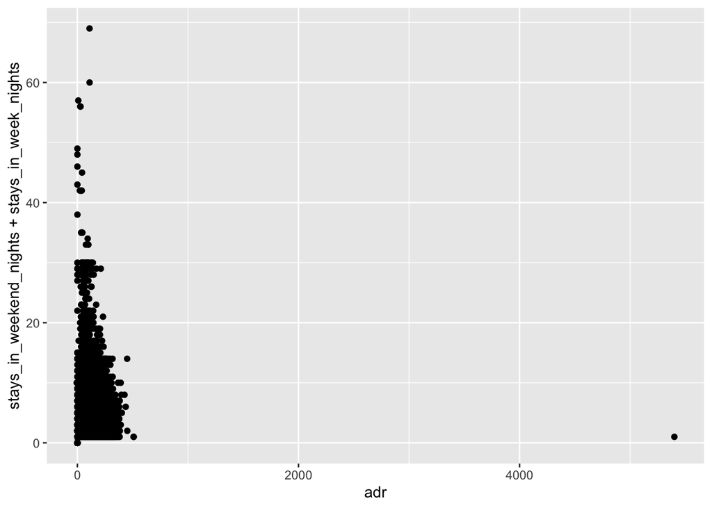

```r
ggplot(hotels,
       aes(x = adr, y = stays_in_weekend_nights+stays_in_week_nights)) +
  geom_point()
```

Clearly there was one very expensive room booking!

`dplyr` uses the pipe operator `%>%` in order to string together different commands and we can do this right in line with the plot command.

We’ll change one other thing … there is a lot of overplotting, so we can make the scatter plot partially transparent with the `alpha = 0.1` argument.

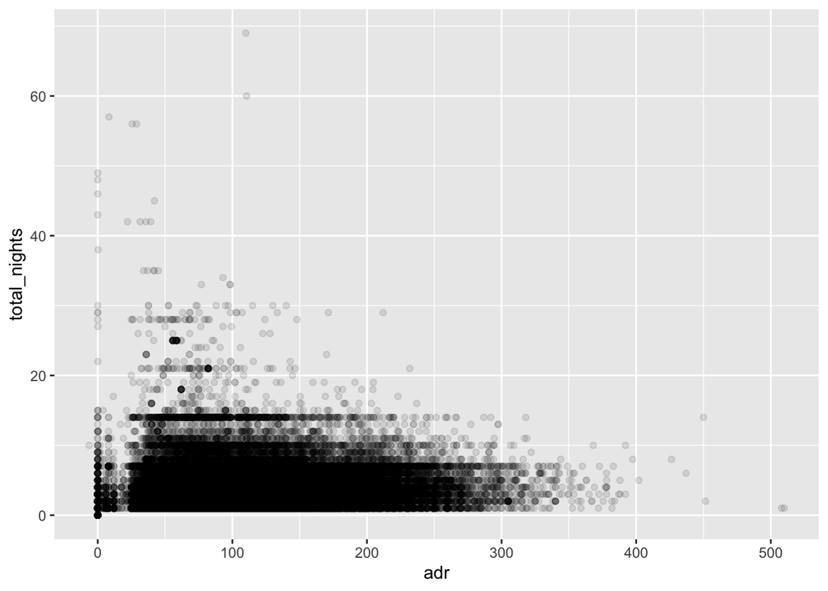

```r
ggplot(hotels %>%
         filter(adr < 4000) %>%
         mutate(total_nights = stays_in_weekend_nights+stays_in_week_nights),
       aes(x = adr, y = total_nights)) +
  geom_point(alpha=0.1)
```

Notice that the `hotels` data frame has not actually changed, the result of the `dplyr` commands are passed straight to the `ggplot()` function. We can store these results by instead writing them back to the original data frame, or to somewhere new:

```r
hotels <- hotels %>%
  filter(adr < 4000) %>%
  mutate(total_nights = stays_in_weekend_nights+stays_in_week_nights)
```

In the plot it is clearly still hard to see, so we can just switch from a scatter plot (`geom_point()`) to a heatmap (`geom_bin2d()`), where we set the bins to be in cost size 10 and 1 night. Now, we just need to provide the data frame as we have saved the results of our manipulation.

We can layer on top other elements, for example we can add a simple smoothed line for the expected number of nights at each price point to see if there is actually any likely trend by just adding a `geom_smooth()` to the plot.

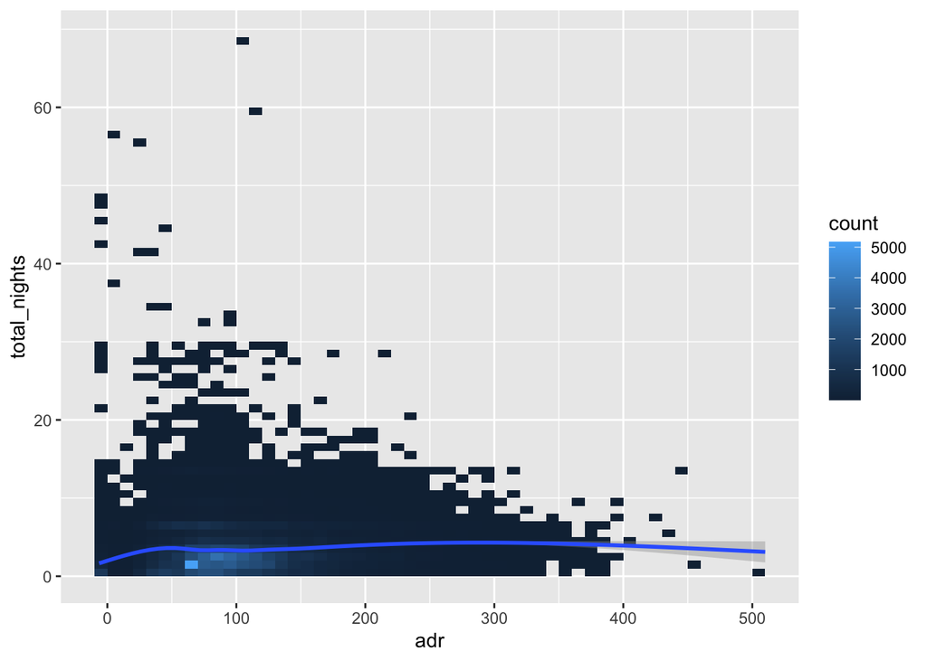

```r
ggplot(hotels,
       aes(x = adr, y = total_nights)) +
  geom_bin2d(binwidth=c(10,1)) +
  geom_smooth()
```

Let us focus now on some more data manipulation in preparation for trying to see if we can predict in advance what bookings might get cancelled. Looking at the data, we need to tidy things up a little, including:

- eliminating variables that are not appropriate to use for prediction … for example, if you read the web page earlier describing the variables, we should clearly eliminiate `reservation_status` and `reservation_status_date`
- we may choose to transform other variables, for example rather than having a total number of children and of babies, perhaps we just want an indicator for there being kids in the booking.

We will use `dplyr` to manipulate the data in this way. We saw `filter()` and `mutate()` above. We will learn 2 more of these:

- `select` can be used to choose among or to remove variables. Putting a minus in front indicates removal.
- `case_when` is used to return one of a set of possible values based on a condition. Each observation is compared against the condition on the left of the tilde `~` symbol *in order* and the first matching case results in the expression on the right being returned.

For example, let’s perform the above steps:

```r
hotels <- hotels %>%
  select(-reservation_status, -reservation_status_date) %>%
  mutate(kids = case_when(
    children + babies > 0 ~ "kids",
    TRUE ~ "none"
  ))
```

Now that we have our indicator for kids, we don’t actually need the `babies` and `children` variables any more. Replace each `?` below with the correct code to remove them.

```r
hotels <- hotels %>%
  ?(?)
```

```r
hotels <- hotels %>%
  select(-babies, -children)
```

We are also not interested in how many parking spaces are needed, just if one was requested or not. Replace each `?` below with the correct code to:

- create a new variable called `parking` which is either “parking” or “none” depending on the `required_car_parking_spaces` variable value
- then remove the `required_car_parking_spaces` variable.

```r
hotels <- hotels %>%
  mutate(? = case_when(
    ? ~ ?,
    TRUE ~ "none"
  )) %>%
  select(?)
```

```r
hotels <- hotels %>%
  mutate(parking = case_when(
    required_car_parking_spaces > 0 ~ "parking",
    TRUE ~ "none"
  )) %>%
  select(-required_car_parking_spaces)
```

Look at the data and confirm that all the above steps have happened.

It can be time consuming to check lots of plots like above one-by-one. Instead, we can look at a pairs plot to examine the pairwise relationships between some variables of interest. For example,

```r
library("GGally")
```

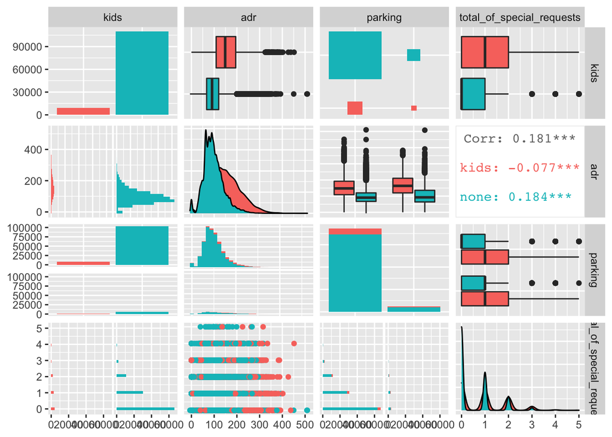

```r
ggpairs(hotels %>% select(kids, adr, parking, total_of_special_requests),
        aes(color = kids))
```

Can you interpret what is being plotted here? Ask for help if not!

We could check to see if different countries have different cancellation rates by manipulating the data. To do this, we need to learn further `dplyr` commands:

- `group_by` specifies the variables that you want to construct summary information by
- `summarise` constructs new summary statistics computed for each group defined by the grouping variables. There are common functions such as `n()` (total number in that group) and `sum()` (adding up another variable) and `mean()` etc. Notice that you can also reference variables you just created.

```r
hotels.bycountry <- hotels %>%
  group_by(country) %>%
  summarise(total = n(),
            cancellations = sum(is_canceled),
            pct.cancelled = cancellations/total*100)
```

Inspect the new data frame `hotels.bycountry`. There are a lot of countries, but we could visualise the top 10 by the total number of bookings.

- `arrange()` allows us to sort (ascending by default, descending if you use `desc()`)
- `head()` retains just the specified number of rows.

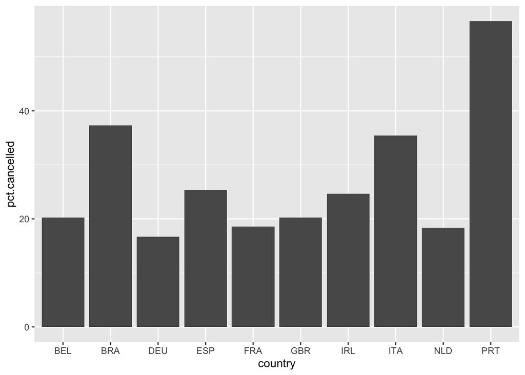

```r
ggplot(hotels.bycountry %>% arrange(desc(total)) %>% head(10),
       aes(x = country, y = pct.cancelled)) +
  geom_col()
```

However, it may be most interesting to view this on a world map, which can also be easily achieved with `ggplot`.

First, we load mapping data from associated libraries

```r
library("rnaturalearth")
library("rnaturalearthdata")
library("rgeos")
world <- ne_countries(scale = "medium", returnclass = "sf")
```

If you inspect the `world` object you will find mapping information about 241 countries. In particular, the `iso_a3` variable appears to contain ISO country code like the hotel data.

All we need to do is to attach the `hotels.bycountry` data to the world data using the ISO codes in the `country` variable to match rows.

This involves the `dplyr` function `left_join()`. This function takes the name of the data frame you want to attach and then the names of the key variable to match in each data frame. Crucially, whichever data frame is fed to `left_join()` will retain all its rows, even when there is no matching row in the data frame being joined to it (so we won’t lose parts of the map from which nobody booked a room)

```r
world2 <- world %>%
  left_join(hotels.bycountry,
            by = c("iso_a3" = "country"))
```

Inspect the data frame and see that the `total`, `cancellations` and `pct.cancelled` variables have all been added. Notice that any country that was not present now has `NAs` for these values.

We can now plot the map with `ggplot` and set the fill colour of each country to be the percentage of customers who cancelled.

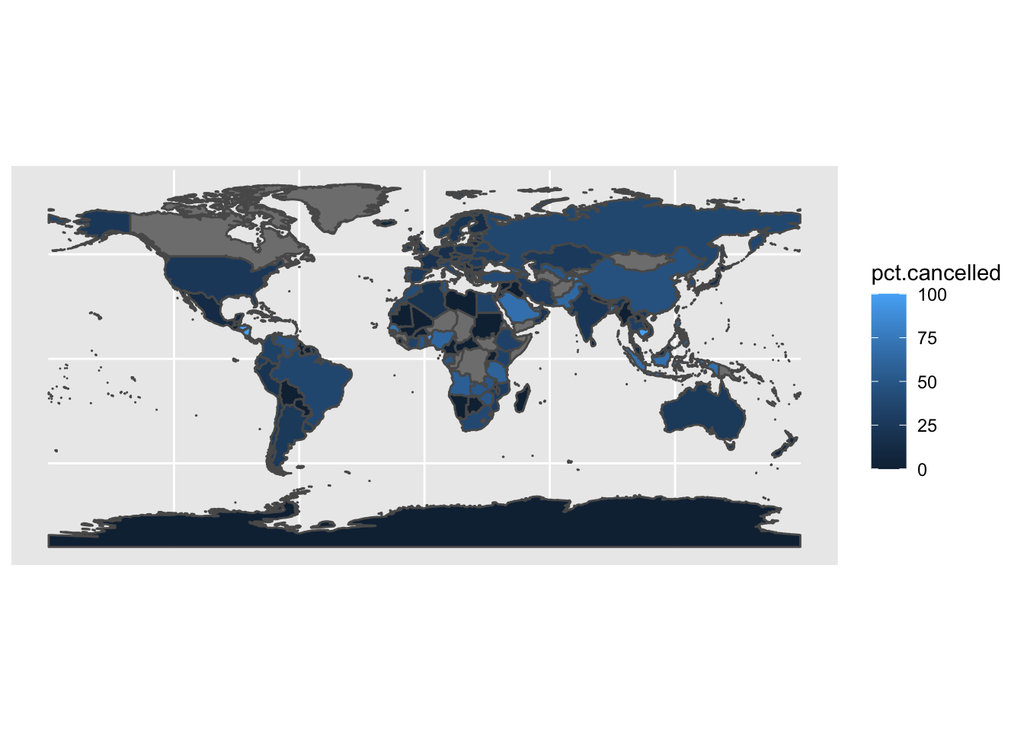

```r
ggplot(world2) +
  geom_sf(aes(fill = pct.cancelled))
```

Finally, we can look at the relation between different discrete variables with a parallel sets diagram, by cancellation status.

We do this by first summarising the discrete levels we want to examine like before:

```r
hotels.par <- hotels %>%
  select(hotel, is_canceled, kids, meal, customer_type) %>%
  group_by(hotel, is_canceled, kids, meal, customer_type) %>%
  summarize(value = n())
```

Inspect the `hotels.par` object and make sure you understand what this code has done. Now we can visualise the relationship between levels and the cancellation status:

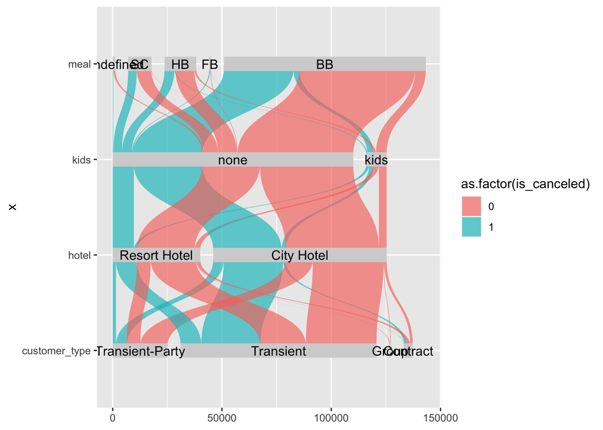

```r
library("ggforce")

ggplot(hotels.par %>% gather_set_data(x = c(1, 3:5)),
       aes(x = x, id = id, split = y, value = value)) +
  geom_parallel_sets(aes(fill = as.factor(is_canceled)),
                     axis.width = 0.1,
                     alpha = 0.66) +
  geom_parallel_sets_axes(axis.width = 0.15, fill = "lightgrey") +
  geom_parallel_sets_labels(angle = 0) +
  coord_flip()
```

## Fitting a first statistical machine learning model

We will now fit a logistic regression model as seen in lectures. Now, note that we have a lot of categorical variables, so as we know from the second lecture these need to be made numeric and that for a linear model like logistic regression we should use a *dummy coding*. Fortunately for us, the built in R function `glm()` will do this for us. However, look back at the output of `skim` right at the start of this practical: the first group of variables (of type `character`) are the categorical ones. Do you think we should remove some of these? Why? (Hint: look at the `n_unique` column)

ANSWER: Yes, some of the categorical variables have a lot of unique levels and when we create a dummy encoding we will end up with many more variables in the model. For example, `agent` has 334 unique values, so we would turn `agent` from a single variable into 333 new variables!

Remove:

- all categorical variables with 10 or more unique levels, except for `arrival_date_month`.
- `stays_in_weekend_nights` and `stays_in_week_nights`. Why?

ANSWER: the two stays variables are a linear combination of the new variable we created earlier in the lab (total nights) and so the design matrix would be singular and cause problems with fitting.

```r
hotels2 <- hotels %>%
  select(-country, -reserved_room_type, -assigned_room_type, -agent, -company,
         -stays_in_weekend_nights, -stays_in_week_nights)
```

We can now fit a logisitic regression model to predict the `is_canceled` variable based on all others in the data set. We tell R this is the goal by first converting `is_canceled` to a `factor` type and then make a *formula* by typing `as.factor(is_canceled) ~ .` … the `~` symbol is read “is predicted by” and the `.` is read “everything else in the dataset”. So:

*`is_canceled` is a factor which is predicted by everything else in the dataset*

We could also manually list variables separated by `+` but there are a lot!

```r
fit.lr <- glm(as.factor(is_canceled) ~ ., binomial, hotels2)
```

The model is now stored in `fit.lr`. Have a look at the detailed output:

```r
summary(fit.lr)
```

```
##
## Call:
## glm(formula = as.factor(is_canceled) ~ ., family = binomial,
##     data = hotels2)
##
## Deviance Residuals:
##     Min       1Q   Median       3Q      Max
## -8.4904  -0.7372  -0.4192   0.2061   5.8712
##
## Coefficients:
##                                  Estimate Std. Error z value Pr(>|z|)
## (Intercept)                    -4.809e+01  3.581e+01  -1.343 0.179254
## hotelResort Hotel               7.654e-02  1.892e-02   4.045 5.22e-05 ***
## lead_time                       4.052e-03  1.044e-04  38.831  < 2e-16 ***
## arrival_date_year               2.363e-02  1.769e-02   1.336 0.181666
## arrival_date_monthAugust        2.324e+00  3.501e-01   6.638 3.19e-11 ***
## arrival_date_monthDecember      5.038e+00  6.981e-01   7.216 5.34e-13 ***
## arrival_date_monthFebruary     -1.055e+00  1.748e-01  -6.034 1.60e-09 ***
## arrival_date_monthJanuary      -1.803e+00  2.631e-01  -6.853 7.24e-12 ***
## arrival_date_monthJuly          1.608e+00  2.615e-01   6.151 7.71e-10 ***
## arrival_date_monthJune          1.087e+00  1.785e-01   6.090 1.13e-09 ***
## arrival_date_monthMarch        -7.324e-01  9.614e-02  -7.618 2.57e-14 ***
## arrival_date_monthMay           5.149e-01  9.349e-02   5.508 3.63e-08 ***
## arrival_date_monthNovember      4.317e+00  6.140e-01   7.031 2.06e-12 ***
## arrival_date_monthOctober       3.646e+00  5.253e-01   6.941 3.89e-12 ***
## arrival_date_monthSeptember     2.869e+00  4.395e-01   6.526 6.73e-11 ***
## arrival_date_week_number       -1.386e-01  2.002e-02  -6.922 4.46e-12 ***
## arrival_date_day_of_month       2.017e-02  3.011e-03   6.699 2.10e-11 ***
## adults                          9.167e-02  1.472e-02   6.228 4.72e-10 ***
## mealFB                          6.667e-01  1.076e-01   6.197 5.74e-10 ***
## mealHB                         -1.474e-01  2.704e-02  -5.453 4.96e-08 ***
## mealSC                          1.520e-01  2.546e-02   5.970 2.38e-09 ***
## mealUndefined                  -6.468e-01  9.988e-02  -6.475 9.45e-11 ***
## market_segmentComplementary     5.858e-01  2.232e-01   2.624 0.008694 **
## market_segmentCorporate        -2.064e-01  1.758e-01  -1.174 0.240505
## market_segmentDirect            4.382e-02  1.945e-01   0.225 0.821749
## market_segmentGroups           -2.346e-02  1.838e-01  -0.128 0.898438
## market_segmentOffline TA/TO    -6.215e-01  1.845e-01  -3.369 0.000754 ***
## market_segmentOnline TA         7.112e-01  1.839e-01   3.867 0.000110 ***
## market_segmentUndefined        -7.157e+02  3.875e+07   0.000 0.999985
```

[output cut: 14 more lines]

```
## adr                             4.958e-03  2.356e-04  21.040  < 2e-16 ***
## total_of_special_requests      -7.333e-01  1.150e-02 -63.772  < 2e-16 ***
## total_nights                    5.241e-02  3.180e-03  16.483  < 2e-16 ***
## kidsnone                       -1.640e-01  2.888e-02  -5.679 1.35e-08 ***
## parkingparking                 -1.538e+03  7.793e+05  -0.002 0.998425
## ---
## Signif. codes:  0 '***' 0.001 '**' 0.01 '*' 0.05 '.' 0.1 ' ' 1
##
## (Dispersion parameter for binomial family taken to be 1)
##
##     Null deviance: 157396  on 119388  degrees of freedom
## Residual deviance: 102337  on 119341  degrees of freedom
## AIC: 102433
##
## Number of Fisher Scoring iterations: 12
```

Do you think the sign and significance of the different predictors makes intuitive sense?

ANSWER: It looks like it does in many cases. For example, `is_repeated_guest` is negative, meaning repeated guests are less likely to cancel. Also, `previous_cancellations` is positive, meaning people who have cancelled before are more likely to cancel again. This and many other fitted coefficients seem to be logical.

We could carry on now to look at the predictions the model makes. We ask for `type="response"` so that we get probabilities and not the linear model part:

```r
pred.lr <- predict(fit.lr, hotels2, type = "response")
```

We might even look at a histogram plot of these predictions:

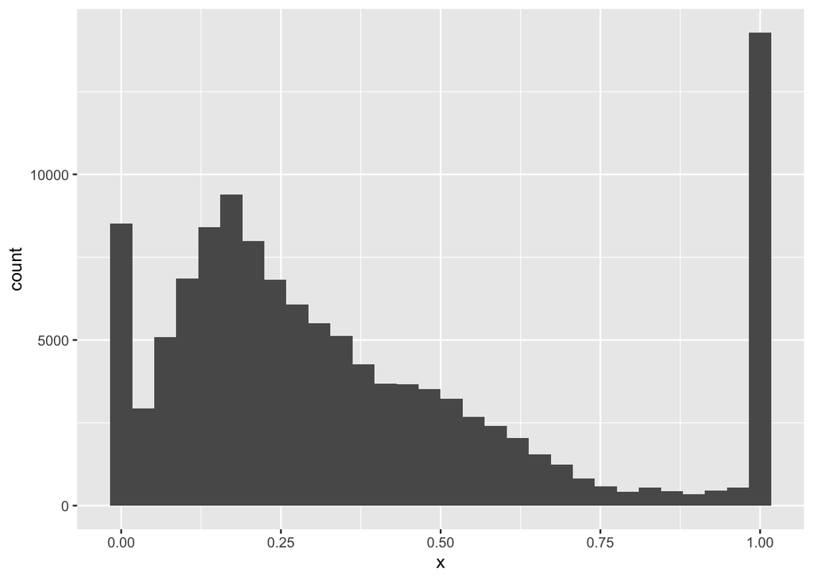

```r
ggplot(data.frame(x = pred.lr), aes(x = x)) + geom_histogram()
```

We can see that the model seems to make some very confident predictions of cancellations and non-cancellations, with a skewed spread of more uncertain predictions. It seems very sure of around 22 thousand, so of roughly 18% of the data and then less certain of the rest.

Let’s see how it does by comparing these predictions to the actual responses. Hoping that we have got a “true” model here, we’ll just use the Bayes prediction in other words, take the arg max over classes. That means we predict cancellation if the probability of cancellation is over 0.5, but of course we do not *have* to make this choice.

```r
conf.mat <- table(`true cancel` = hotels2$is_canceled, `predict cancel` = pred.lr > 0.5)
conf.mat
```

```
##            predict cancel
## true cancel FALSE  TRUE
##           0 70130  5036
##           1 17725 26498
```

The above is called a “confusion matrix” and we can read off for example:

We can then output for example the class conditional accuracy percentages as:

```r
conf.mat/rowSums(conf.mat)*100
```

```
##            predict cancel
## true cancel     FALSE      TRUE
##           0 93.300162  6.699838
##           1 40.080953 59.919047
```

Do you think this model could be useful to a hotel chain or booking website?

Imagine that the hotel policy is only to charge one night if there is a cancellation and to refund the other nights. Then, we could setup our model to overbook capacity when people appear likely to cancel (for example is is common to overbook in the airline industry). How might you explore this?

Some important final comments:

- What we have done above, calculating the accuracies on the same data we used to fit the model, is **NOT** a good idea. We will see in lectures why it is bad and how to do better!
- All the different accuracies we tried to calculate above are super important in a variety of different ways. Again, we’ll learn more about sensitivity, specificity, etc in lectures soon.

Using these results, explore the plotting options at:

https://ggplot2.tidyverse.org/

and the data manipulation reference at:

https://dplyr.tidyverse.org/

to explore the relationship between the variables rated important and the bookings that are cancelled.

If you exhaust this, then explore some of the visualisations others presented on Twitter at [#tidytuesday](https://twitter.com/search?q=%23tidytuesday).